# Project: WeRateDog Udacity

# 1. Introduction

WeRateDogs is a twitter handle that rates pictures of dogs that are posted on twitter by different dog owners and people.Data was gathered from csv and tsv files and via twitter APIs to analyze the tweets as part of the aim of this project.A total of 2356 tweets was properly cleaned, investigated, insights were generated and effectively communicated as seen below

### first insight

WeRateDogs has various rating schemes which is dependent on the investigation been carried out. However, 26% of people did not post dog pictures based on the image prediction.This could stem from the fact that entitle people hardly follow instructions since to them it is 'unfair' as stated by Zitek & Jordan(2017).It is then pertinent to deduce that about 26% of WeRateDogs rendezvous are entitle people.

### Visualization

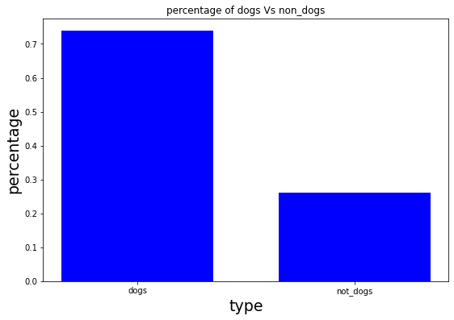

```python
# setting figure size and label
fig = plt.figure(figsize = (9,6))

plt.bar(animal,values,color='blue',width=0.7)
plt.title('percentage of dogs Vs non_dogs')
plt.xlabel('type',fontsize=19)
plt.ylabel('percentage',fontsize=19)
plt.show()
```

### second Insight

.The most user rendezvous month on average on WeRateDogs twitter handle from 2015-11-15 to 2017-08-01 is June. This implies that spanning the two years, most people were very active in the month of June liking and sharing tweets

```python
mean_fav_count = master.groupby('month')['favorite_count'].mean().values
```

```python
months = ['Jan','Feb','Mar','Apr','May','Jun','Jul','Aug','Sep','Oct','Nov','Dec']
```

### Visualization

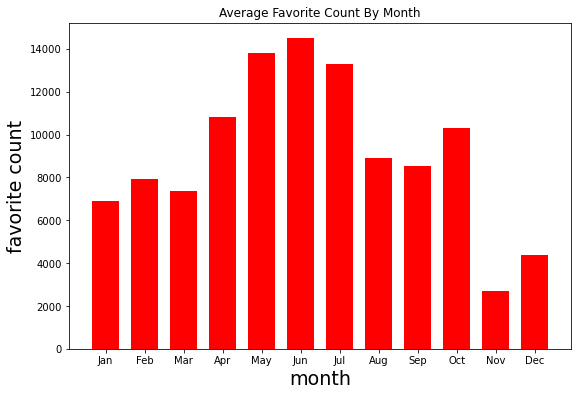

```python
# setting figure size and labels
fig = plt.figure(figsize = (9,6))

plt.bar(months,mean_fav_count,color='Red',width=0.7)
plt.xlabel('month',fontsize=19)
plt.ylabel('favorite count',fontsize=19)
plt.title('Average Favorite Count By Month')
plt.show()
```

### Third Insight

There was a moderate correlation between rating_numerator and favorite_count. However, this correlation coefficient of 0.35 is a positive one in trend

```python
favorite_count = master.favorite_count.values
rating_numerator = master.rating_numerator.values
```

```python
correlation = master.favorite_count.corr(master.rating_numerator)
correlation
```

```
0.3552502474789611
```

### Visualization

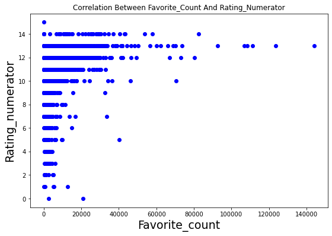

```python
# setting figure size and labels
fig = plt.figure(figsize=(9,6))

plt.scatter(favorite_count,rating_numerator, color='blue')
plt.xlabel('Favorite_count',fontsize=19)
plt.ylabel('Rating_numerator',fontsize=19)
plt.title("Correlation Between Favorite_Count And Rating_Numerator")
plt.show()
```

### Fourth Insight

From November 2015 to August 2017, dogs in the puppo identifer had more favorite count on the average on the WeRateDog twitter account followed by doggo, and the least is pupper.

```python
mean_fav_count = master.groupby('identifer')['favorite_count'].mean().values
dog_identifer = master.groupby('identifer')['favorite_count'].mean().index
```

### Visualization

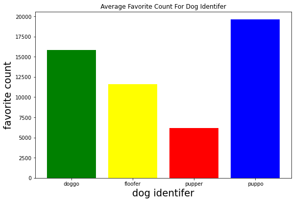

```python
# setting figure size and labels
fig = plt.figure(figsize=(9,6))

plt.bar(dog_identifer,mean_fav_count, color=['green','yellow','red','blue'])
plt.xlabel('dog identifer',fontsize=19)
plt.ylabel('favorite count',fontsize=19)
plt.title("Average Favorite Count For Dog Identifer")
plt.show()
```

### Reference

Emily M.Zitek, Alexander H.Jordan(2017),'Psychological Entitlement Predicts Failure to Follow Instructions',Journal of Social Psychological and Personality Science.[Online]Available from:https://www.sciencedaily.com/releases/2017/12/171220121733.htm (Accessed: 17th September 2022)